# Naive Bayes Classifier

Danial Saeedi(810198571)

# Import Dependencies

```python
!pip install hazm
!pip install parsivar
```

```python
from __future__ import unicode_literals
import re
import math
from hazm import *
import hazm
import parsivar
import numpy as np
import pandas as pd
from prettytable import PrettyTable
import matplotlib.pyplot as plt
from math import log
```

# Importing the dataset

```python
!mkdir dataset/
```

```python
!unzip /content/drive/MyDrive/Data.zip -d ./dataset
```

```
Archive:  /content/drive/MyDrive/Data.zip
  inflating: ./dataset/train.csv
  inflating: ./dataset/test.csv
```

```python
df_train = pd.read_csv('dataset/train.csv')
df_test = pd.read_csv('dataset/test.csv')
```

```python
df_train['label'].unique()
```

```
array(['هنر و سینما', 'علم و تکنولوژی', 'سلامت و زیبایی', 'بازی ویدیویی'],
      dtype=object)
```

```python
df_test['label'].value_counts()
```

```
علم و تکنولوژی    277
بازی ویدیویی      197
هنر و سینما       167
سلامت و زیبایی    161
Name: label, dtype: int64
```

# Part 1: Pre-processing Data

```python
stop_words = set(hazm.stopwords_list("stopwords.txt"))
```

```python
def clean_data(text):
    # Removing stop words
    text = str(text)
    words = [word for word in text.split() if word not in stop_words]
    text = " ".join(words)

    normalizer = Normalizer()

    text = normalizer.normalize(text)

    # Split and remove useless chars
    text_words = text.split()
    for i in [',', '.', '-', '*', '!','?','(',')','،','؛',':','؟']:
        text_words = [x.strip(i) for x in text_words]

    stemmer = Stemmer()
    lemmatizer = Lemmatizer()

    cleaned = []
    for word in text_words:
        s = stemmer.stem(word)
        l = lemmatizer.lemmatize(s)

        cleaned.append(l)

    # To list
    return " ".join(list(dict.fromkeys(cleaned)))
```

```python
print(clean_data(df_train.iloc[1]['content']))
```

```
پنج فیلمساز که کوئنتین تارانتینو عاشق سینما کرد#کن ک یک ماه اکر مهم فیل مانده اس البته دو مه داشت#دار مرد ایرلند اسکورسیز فهرس انتظار #است خوره فیلم منتظر دیدن روز روزگار هالیوود #هست آدم کتاب رو تاثیر گذاشت#گذار آن‌قدر مفصل شد#شو ویدیو همه بررس بیل بک پالپ فیکشن بقیه توانست#توان المان آن گرفته کشف …
```

```python
df_train['label'].value_counts()
```

```
هنر و سینما       1300
علم و تکنولوژی    1300
سلامت و زیبایی    1300
بازی ویدیویی      1300
Name: label, dtype: int64
```

# Question 1

## Stemming

We're going to use Hazm Stemmer in order to remove or stem the last few characters of the words that are not important such as ها in کتاب‌ها.

## Lemmatization

We're going to use Hazm Lemmatizer in order to convert the word to its meaningful base form, which is called Lemma.

# Question 2

$$ P(c|x) = \frac{P(x|c)P(c)}{P(x)} $$

- **Posterior** is the probability that the event `c` will occur given the knowledge that an event `x` has already occurred. In this problem, posterior is the probability of the occurness of the class `c` given the word `x`. This can be computed by the given formula. We will compare this probability for 4 classes to choose one of the classes for the given content.
- **Prior** is the probability of the the class `c`. We know that the training data is **symmetric**. Therefore, we do not need to compute it and it will be $1/4=0.25$. But if we didn't had this assumption, we could compute it by dividing the frequency of the class c by the sum of the frequency of all the classes in the training data.
- **Likelihood** is the probability that the event `x` will occur given the knowledge that an event `c` has already occurred. In this problem, likelihood is the probability of the occurness of the word `x` given the class `c` that can be one of the 4 classes. This probability can be computed by dividing the frequency of the word `x` in the class `c` by the sum of frequency of all the words in the class `c`.
- **Evidence** is the probability of the `x` used to update the prior. In this problem, evidence is the probability of the occurness of the word `x` in the given text. It can be easily computed by dividing the frequency of the word `x` by the sum of the frequency of all the words in the text. But we do not need to compute this probability because we want to compare two classes and this parameter is same for all classes, so we can ignore it.

# Question 3

Consider this example:

```
 بیا و برگ سفر ساز و زاد ره برگیر           که عاقبت برود هر که او ز مادر زاد
```

As you can see, زاد has two different meaning depending on the position of the words. Therefore, these two verses have completely different concepts.

Using bigram for this sentence would be better than unigram because مادر زاد and زاد سفر could be a much better indicator. In this example bigram is enough.

**Note:** Bigrams could also be used to increase accuracy. Here we only consider a word by itself and not its position in the sentence.

# Question 4

In case that there is word contained only one type of class, Naive Bayes will definetly choose that genre as the answer which might be wrong in some cases.

When word $x$ hasn't appeared in genre $c$, we have that $P(x|c) = 0$ The reason is that $log(0) = - \infty$ so the sum $ sum_{i=1}^{n} log(P(x_i | c)) $ will converge to $- \infty$ and never will be chosen as the genre since wre choosing the genre which maximizes the sum mentioned above.

# Question 5

Additive Smoothing is a technique to smooth categorical data. This technique is introduced to solve the problem of zero probability. A small-sample correction, or pseudo-count, will be incorporated in every probability estimate. Consequently, o probability will be zero. this is a way of regularizing Naive Bayes. Based on the formula, we have a parameter called smoothing that is shown by lambda and K is the number of the unique words in the training data.

Here's how we calculate probability:

$$ P(Word|Class) = \frac{WC + \alpha}{TW + \alpha.D} $$

- WC: Word Count
- TW: Total Words

Where $\alpha$ is a positive constant and $D$ is the number of distinct words in that category.

This will avoid the $- \infty$ problem mentioned in Question 4 since the fraction will never be equal to 0 because of the positive $\alpha$ in the numerator.

# Part 2

```python
art_cinema = dict()
science_tech = dict()
beauty_health = dict()
video_games = dict()
```

```python
art_cinema_count = 0
science_tech_count = 0
beauty_health_count = 0
video_games_count = 0
```

```python
for index, row in df_train.iterrows():
    tokens = word_tokenize(clean_data(row['content']))
    for token in tokens:
        cat = row['label']
        if (cat == 'بازی ویدیویی'):
            video_games[token] = video_games.get(token, 0) + 1
            video_games_count += 1

        elif (cat == 'سلامت و زیبایی'):
            beauty_health[token] = beauty_health.get(token, 0) + 1
            beauty_health_count += 1

        elif (cat == 'علم و تکنولوژی'):
            science_tech[token] = science_tech.get(token, 0) + 1
            science_tech_count += 1

        elif (cat == 'هنر و سینما'):
            art_cinema[token] = art_cinema.get(token, 0) + 1
            art_cinema_count += 1
```

```python
distinct_art_cinema = len(list(art_cinema.keys()))
distinct_science_tech = len(list(science_tech.keys()))
distinct_beauty_health = len(list(beauty_health.keys()))
distinct_video_games = len(list(video_games.keys()))
```

# Question 6

## Art & Cinema

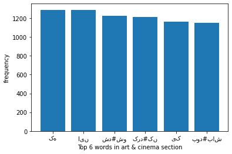

```python
from matplotlib import pyplot as plt
from operator import itemgetter

res = dict(sorted(art_cinema.items(), key = itemgetter(1), reverse = True)[:6])
keys = res.keys()
values = res.values()
plt.bar(keys, values)
plt.xlabel('Top 6 words in art & cinema section')
plt.ylabel('frequency')
plt.show()
```

```python
dict(sorted(art_cinema.items(), key = itemgetter(1), reverse = True)[:6])
```

```
{'این': 1285,
 'بود#باش': 1146,
 'شد#شو': 1222,
 'کرد#کن': 1210,
 'که': 1287,
 'یک': 1163}
```

## Science & Tech

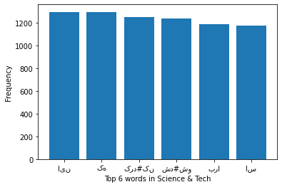

```python
res = dict(sorted(science_tech.items(), key = itemgetter(1), reverse = True)[:6])
keys = res.keys()
values = res.values()
plt.bar(keys, values)
plt.xlabel('Top 6 words in Science & Tech')
plt.ylabel('Frequency')
plt.show()
```

```python
dict(sorted(art_cinema.items(), key = itemgetter(1), reverse = True)[:6])
```

[output not shown]

## Beauty & Health

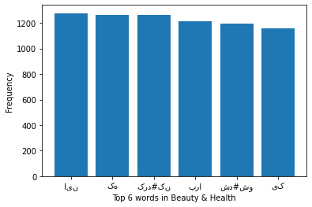

```python
res = dict(sorted(beauty_health.items(), key = itemgetter(1), reverse = True)[:6])
keys = res.keys()
values = res.values()
plt.bar(keys, values)
plt.xlabel('Top 6 words in Beauty & Health')
plt.ylabel('Frequency')
plt.show()
```

```python
dict(sorted(beauty_health.items(), key = itemgetter(1), reverse = True)[:6])
```

```
{'این': 1277,
 'برا': 1212,
 'شد#شو': 1197,
 'کرد#کن': 1263,
 'که': 1264,
 'یک': 1161}
```

## Video Games

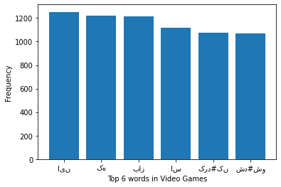

```python
res = dict(sorted(video_games.items(), key = itemgetter(1), reverse = True)[:6])
keys = res.keys()
values = res.values()
plt.bar(keys, values)
plt.xlabel('Top 6 words in Video Games')
plt.ylabel('Frequency')
plt.show()
```

```python
dict(sorted(video_games.items(), key = itemgetter(1), reverse = True)[:6])
```

```
{'اس': 1118,
 'این': 1252,
 'باز': 1212,
 'شد#شو': 1071,
 'کرد#کن': 1074,
 'که': 1219}
```

# Util

```python
def printResult(tp,fp,fn,correct):
    for i in range(4):
        precision = tp[i] / (tp[i] + fp[i])
        recall = tp[i] / (tp[i] + fn[i])
        F1_score = (2 * precision * recall) / (precision + recall)

        print("Category ", i)
        print("True Positive Count: ", tp[i])
        print("False Positive Count: ", fp[i])
        print("False Negative Count: ", fn[i])
        print("Precision:", precision)
        print("F1_score:", F1_score)
        print("Recall:", recall)
        print("------------------------------")

    print("Accuracy is ", correct/len(df_test))
```

# Question 7

If the model always labels every data a specific class(like video games), the **recall** value for video games category will be 100%. Obviously this is not good. So recall metric alone is not enough to evaluate a model.

**Precision** alone is not enough to evaluate a model. Consider a model that wrongly detects all the contetns as video games class except one content that is really recommended. Therefore the precision of this model will be 1. Obviously this is not good. So precision metric alone is not enough to evaluate a model.

# Question 8

The F1 score is the harmonic mean of precision and recall taking both metrics into account. It uses the harmonic mean instead of a simple average because it punishes extreme values. A classifier with a precision of 1.0 and a recall of 0.0 has a simple average of 0.5 but an F1 score of 0.

# Question 9:

- **Micro:** computes f1 by value total true positives, false negatives and false positives (no matter of the prediction for each label in the dataset)
- **Macro:** computess f1 for each label, and returns the average without considering the proportion for each label in the dataset.
- **Weighted:** computes f1 for each label, and returns the average considering the proportion for each label in the dataset.

# Question 10:

## Without additive smoothing

```python
def get_category_index(cat):
    genres = ['هنر و سینما', 'علم و تکنولوژی', 'سلامت و زیبایی', 'بازی ویدیویی']
    return genres.index(cat)

get_category_index('بازی ویدیویی')
```

```
3
```

```python
tp = [0, 0, 0, 0]
fp = [0, 0, 0, 0]
fn = [0, 0, 0, 0]
correct = 0
```

```python
ZERO = 1/999999999999999999999999999999999999999999999

def get_class_prob(cat,cat_count,t):
    if (t not in cat):
        return log(ZERO)
    else:
        return log((cat[t]) / (cat_count))

def calculate_prob_without_additive_smoothing(content):
    tokens = word_tokenize(clean_data(content))
    class_prob = [0, 0, 0, 0]


    for token in tokens:

        class_prob[0] += get_class_prob(art_cinema,art_cinema_count,token)

        class_prob[1] += get_class_prob(science_tech,science_tech_count,token)

        class_prob[2] += get_class_prob(beauty_health,beauty_health_count,token)

        class_prob[3] += get_class_prob(video_games,video_games_count,token)


    return class_prob
```

```python
for index, row in df_test.iterrows():

    prob_over_classes = calculate_prob_without_additive_smoothing(row['content'])

    max_prob_class = max(prob_over_classes)

    predict = prob_over_classes.index(max_prob_class, 0)

    category = get_category_index(row['label'])

    if category == predict:
        correct += 1

    if (category == predict):
        tp[predict] += 1
    else:
        fp[predict] += 1
        fn[category] += 1
```

```python
print("Without additive smoothing:\n")
printResult(tp,fp,fn,correct)
```

```
Without additive smoothing:

Category  0
True Positive Count:  164
False Positive Count:  17
False Negative Count:  3
Precision: 0.9060773480662984
F1_score: 0.9425287356321839
Recall: 0.9820359281437125
------------------------------
Category  1
True Positive Count:  253
False Positive Count:  7
False Negative Count:  24
Precision: 0.9730769230769231
F1_score: 0.9422718808193669
Recall: 0.9133574007220217
------------------------------
Category  2
True Positive Count:  152
False Positive Count:  22
False Negative Count:  9
Precision: 0.8735632183908046
F1_score: 0.9074626865671642
Recall: 0.9440993788819876
------------------------------
Category  3
True Positive Count:  182
False Positive Count:  5
False Negative Count:  15
Precision: 0.9732620320855615
F1_score: 0.9479166666666666
Recall: 0.9238578680203046
------------------------------
Accuracy is  0.9364089775561097
```

$$Precision = \frac{TP_1 + TP_2 + TP_3 + TP_4}{TP_1 + FP_1 + TP_2 + FP_2 + TP_3 + FP_3 + TP_4 + FP_4} = 0.93\$$$$Recall = \frac{TP_1 + TP_2 + TP_3 + TP_4}{TP_1 + FN_1 + TP_2 + FN_2 + TP_3 + FN_3 + TP_4 + FN_4} = 0.93\$$$$ F_1 = 2\frac{Precision.Recall}{Precision + Recall} = 0.93\$$